# Analysis of Variance

多个样本均数的比较，用方差分析。 应用条件： 1. 各样本是相互独立的随机样本，均来自正态分布总体； 2. 相互比较的各样本的总体方差相等，即具有方差齐性。

## 完全随机设计资料的方差分析

完全随机设计资料在进行统计分析时，需根据数据的分布特征选择方法，对于正态分布且方差齐同的资料，采用单因素方差分析（one-factor ANOVA）或成组t检验（g =2）；对于非正态分布或方差不齐的资料，可进行变量变换后采用单向分类方差分析或采用Kruskal-Wallis H检验。

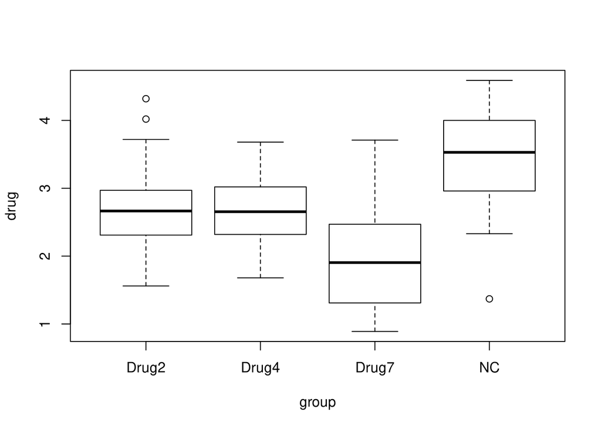

```r
# R中函数AOV（）提供了方差分析的计算与检验，其调用格式如下：
# aov(formula, data = NULL, projections = FALSE, qr = TRUE, contrasts = NULL, ...)
# formula是方差分析的公式，在单因素方差分析中它表示为X～ A，data是数据框。
NC <- c(3.53, 4.59, 4.34, 2.66, 3.59, 3.13, 2.64, 2.56, 3.50, 3.25, 3.3, 4.04, 3.53, 3.56, 3.85, 4.07, 3.52, 3.93, 4.19, 2.96, 1.37, 3.93, 2.33, 2.98, 4.00, 3.55, 2.96, 4.30, 4.16, 2.59)
Drug2 <- c(2.42, 3.36, 4.32, 2.34, 2.68, 2.95, 1.56, 3.11, 1.81, 1.77, 1.98, 2.63, 2.86, 2.93, 2.17, 2.72, 2.65, 2.22, 2.90, 2.97, 2.36, 2.56, 2.52, 2.27, 2.98, 3.72, 2.80, 3.57, 4.02, 2.31)
Drug4 <- c(2.86, 2.28, 2.39, 2.28, 2.48, 2.28, 3.21, 2.23, 2.32, 2.68, 2.66, 2.32, 2.61, 3.64, 2.58, 3.65, 2.66, 3.68, 2.65, 3.02, 3.48, 2.42, 2.41, 2.66, 3.29, 2.70, 3.04, 2.81, 1.97, 1.68)
Drug7 <- c(0.89, 1.06, 1.08, 1.27, 1.63, 1.89, 1.19, 2.17, 2.28, 1.72, 1.98, 1.74, 2.16, 3.37, 2.97, 1.69, 0.94, 2.11, 2.81, 2.52, 1.31, 2.51, 1.88, 1.41, 3.19, 1.92, 2.47, 1.02, 2.10, 3.71)
lip <- data.frame(drug = c(NC, Drug2, Drug4, Drug7), group = factor(rep(c('NC', 'Drug2', 'Drug4', 'Drug7'), each = 30)))
boxplot(drug ~ group, data = lip)
```

```r
drug.aov <- aov(drug ~ group, data = lip)
summary(drug.aov)
```

```
##              Df Sum Sq Mean Sq F value   Pr(>F)
## group         3  32.16  10.719   24.88 1.67e-12 ***
## Residuals   116  49.97   0.431
## ---
## Signif. codes:  0 '***' 0.001 '**' 0.01 '*' 0.05 '.' 0.1 ' ' 1
```

## 随机区组设计资料的方差分析

随机区组设计资料在进行统计分析时，需根据数据分布的特征选择方法，对于正态分布且方差齐同的资料，采用双向分类的方差分析（two-way classification ANOVA）或配对t检验（g=2）；当不满足方差分析或t检验条件时，可进行变量变换后采用双向分类的方差分析或采用Friedman M检验。

```r
# 随机化区组设计的资料的方差分析可以通过调用aov（）函数，调用格式如上，对于formula为y～B +　Ａ（Ｂ是区组因子）
drugA <- c(0.82, 0.73, 0.43, 0.41, 0.68)
drugB <- c(0.65, 0.54, 0.34, 0.21, 0.43)
drugC <- c(0.51, 0.23, 0.28, 0.31, 0.24)
scarma <- data.frame(weight=c(drugA, drugB, drugC), group=rep(c('drugA','drugB','drugC'),each = 5), distri=factor(rep(c(1,2,3,4,5), 3)))
scarma.aov <- aov(weight ~ distri + group, scarma)
summary(scarma.aov)
```

```
##             Df Sum Sq Mean Sq F value  Pr(>F)
## distri       4 0.2284 0.05709   5.978 0.01579 *
## group        2 0.2280 0.11400  11.937 0.00397 **
## Residuals    8 0.0764 0.00955
## ---
## Signif. codes:  0 '***' 0.001 '**' 0.01 '*' 0.05 '.' 0.1 ' ' 1
```

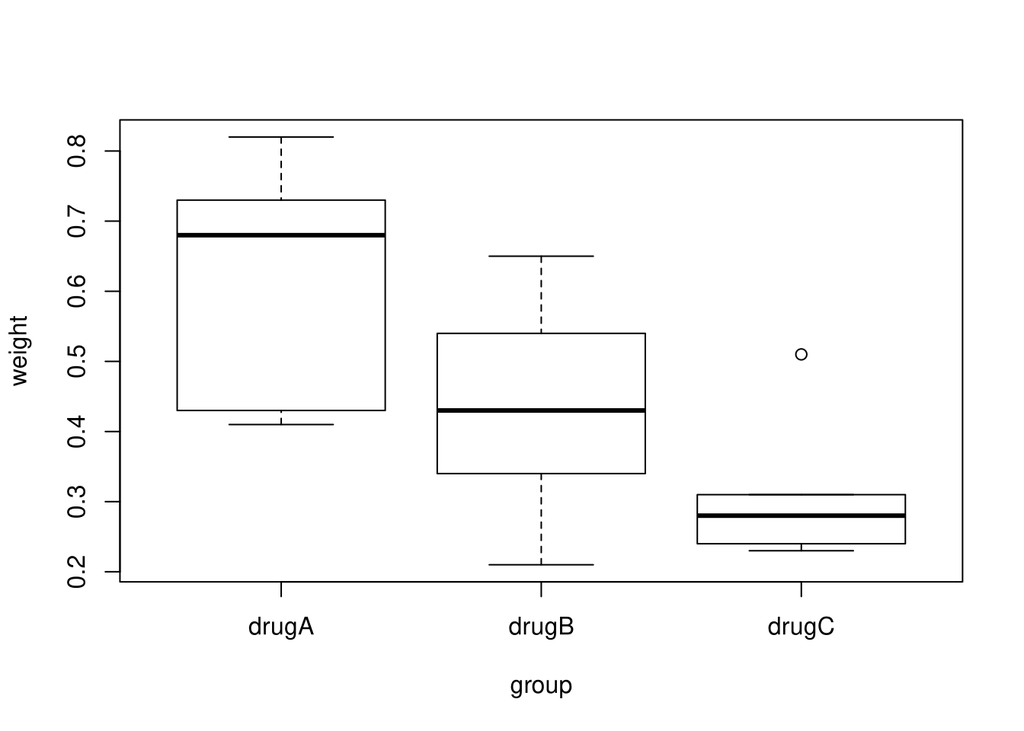

```r
boxplot(weight ~ group, scarma)
```

## 拉丁方设计资料的方差分析

拉丁方设计跟下面的两阶段交叉设计资料，只是随机化区组设计的延伸，其方差分析可以用aov()函数，只需要注意数据输入和formaula了形式。

## 两阶段交叉设计资料的方差分析

在医学研究中，欲将Ａ、Ｂ两种处理先后施加于同一批实验对象，随机地使半数实验对象先接受Ａ后接受Ｂ，而另一半实验对象则正好相反，即先接受Ｂ再接受Ａ。由于两种处理在全部实验过程中交叉进行，这种设计称为交叉设计（crossover design ）。

```r
First <- c(760, 860, 568, 780, 960, 940, 635, 440, 528, 800)
Second <- c(770, 855, 602, 800, 958, 952, 650, 450, 530, 803)
test <- data.frame(mol=c(First, Second), group=rep(c('first','second'), each=10),stage = c('A','B','A','A','B','B','A','B','A','B','B','A','B','B','A','A','B','A','B','A'))
colnames(test) <- c('mol', 'group', 'stage')
test.aov <- aov(mol ~ stage + group, test)
summary(test.aov)
```

```
##             Df Sum Sq Mean Sq F value Pr(>F)
## stage        1    198     198   0.006  0.939
## group        1    490     490   0.015  0.904
## Residuals   17 551506   32442
```

## 多样本均数间的多重比较

当方差分析的结果为拒绝H0,接受H1时，只能说明ｇ个总体均数不全相等。若想进一步了解哪两个总体均数不等，须进行多个样本均数间的两两比较，或多重比较（multiple comparison）。如用两样本均数比较的ｔ检验进行多重比较，将会加大犯Ｉ型错误的概率。 多重比较的方法有如下三种： 1. LSD-t检验； 2. Dunnet-t检验； 3. Turkey检验。

```r
# LSD-t检验:用法：加载agricolae包，使用LSD.test。语法为：LSD.test(y, trt, DFerror, MSerror, alpha = 0.05, p.adj=c("none","holm","hommel", "hochberg", "bonferroni", "BH", "BY", "fdr"), …)
NC <- c(3.53, 4.59, 4.34, 2.66, 3.59, 3.13, 2.64, 2.56, 3.50, 3.25, 3.3, 4.04, 3.53, 3.56, 3.85, 4.07, 3.52, 3.93, 4.19, 2.96, 1.37, 3.93, 2.33, 2.98, 4.00, 3.55, 2.96, 4.30, 4.16, 2.59)
Drug2 <- c(2.42, 3.36, 4.32, 2.34, 2.68, 2.95, 1.56, 3.11, 1.81, 1.77, 1.98, 2.63, 2.86, 2.93, 2.17, 2.72, 2.65, 2.22, 2.90, 2.97, 2.36, 2.56, 2.52, 2.27, 2.98, 3.72, 2.80, 3.57, 4.02, 2.31)
Drug4 <- c(2.86, 2.28, 2.39, 2.28, 2.48, 2.28, 3.21, 2.23, 2.32, 2.68, 2.66, 2.32, 2.61, 3.64, 2.58, 3.65, 2.66, 3.68, 2.65, 3.02, 3.48, 2.42, 2.41, 2.66, 3.29, 2.70, 3.04, 2.81, 1.97, 1.68)
Drug7 <- c(0.89, 1.06, 1.08, 1.27, 1.63, 1.89, 1.19, 2.17, 2.28, 1.72, 1.98, 1.74, 2.16, 3.37, 2.97, 1.69, 0.94, 2.11, 2.81, 2.52, 1.31, 2.51, 1.88, 1.41, 3.19, 1.92, 2.47, 1.02, 2.10, 3.71)
lip <- data.frame(drug = c(NC, Drug2, Drug4, Drug7), group = as.factor(rep(c('NC', 'Drug2', 'Drug4', 'Drug7'), each = 30)))
drug.aov <- aov(drug ~ group, data = lip)
summary(drug.aov)
```

```
##              Df Sum Sq Mean Sq F value   Pr(>F)
## group         3  32.16  10.719   24.88 1.67e-12 ***
## Residuals   116  49.97   0.431
## ---
## Signif. codes:  0 '***' 0.001 '**' 0.01 '*' 0.05 '.' 0.1 ' ' 1
```

```r
library(agricolae)
out <- LSD.test(drug.aov, 'group', p.adj = "bonferroni")
# 注：将LSD.test中p.adj设置为"bonferroni"即为bonferroni检验法， 意用bonferroni法矫正p值。
out
```

```
## $statistics
##     MSerror  Df   Mean      CV  t.value      MSD
##   0.4307502 116 2.7025 24.2855 2.684257 0.454874
##
## $parameters
##         test  p.ajusted name.t ntr alpha
##   Fisher-LSD bonferroni  group   4  0.05
##
## $means
##           drug       std  r      LCL      UCL  Min  Max    Q25   Q50
## Drug2 2.715333 0.6381586 30 2.478002 2.952664 1.56 4.32 2.3175 2.665
## Drug4 2.698000 0.4971671 30 2.460669 2.935331 1.68 3.68 2.3375 2.655
## Drug7 1.966333 0.7464421 30 1.729002 2.203664 0.89 3.71 1.3350 1.905
## NC    3.430333 0.7151247 30 3.193002 3.667664 1.37 4.59 2.9650 3.530
##          Q75
## Drug2 2.9650
## Drug4 2.9800
## Drug7 2.4225
## NC    3.9825
##
## $comparison
## NULL
##
## $groups
##           drug groups
## NC    3.430333      a
## Drug2 2.715333      b
## Drug4 2.698000      b
## Drug7 1.966333      c
##
## attr(,"class")
## [1] "group"
```

```r
#　Dunnet-t检验：适用于多个试验组于一个对照组的比较。
#　用法：加载multcomp包， 使用glht()函数。语法为：glht(model, linfct, alternative = c("two.sided", "less", "greater"), ...)
#　其中linfct可以设置比较的分组变量以及检验方法。
library(multcomp)
rht <- glht(drug.aov, linfct = mcp(group = 'Dunnett'), alternative = 'two.side')
summary(rht)
```

```
##
##   Simultaneous Tests for General Linear Hypotheses
##
## Multiple Comparisons of Means: Dunnett Contrasts
##
##
## Fit: aov(formula = drug ~ group, data = lip)
##
## Linear Hypotheses:
##                    Estimate Std. Error t value Pr(>|t|)
## Drug4 - Drug2 == 0 -0.01733    0.16946  -0.102 0.999233
## Drug7 - Drug2 == 0 -0.74900    0.16946  -4.420  < 1e-04 ***
## NC - Drug2 == 0     0.71500    0.16946   4.219 0.000146 ***
## ---
## Signif. codes:  0 '***' 0.001 '**' 0.01 '*' 0.05 '.' 0.1 ' ' 1
## (Adjusted p values reported -- single-step method)
```

```r
#　Turkey检验：
#　使用t－test进行组间所有成对比较。
#　用法：TukeyHSD函数，语法：TukeyHSD(model)
tuk <- TukeyHSD(drug.aov)
tuk
```

```
##   Tukey multiple comparisons of means
##     95% family-wise confidence level
##
## Fit: aov(formula = drug ~ group, data = lip)
##
## $group
##                    diff        lwr        upr     p adj
## Drug4-Drug2 -0.01733333 -0.4590587  0.4243920 0.9996147
## Drug7-Drug2 -0.74900000 -1.1907253 -0.3072747 0.0001302
## NC-Drug2     0.71500000  0.2732747  1.1567253 0.0002825
## Drug7-Drug4 -0.73166667 -1.1733920 -0.2899413 0.0001938
## NC-Drug4     0.73233333  0.2906080  1.1740587 0.0001909
## NC-Drug7     1.46400000  1.0222747  1.9057253 0.0000000
```

## 多样本方差比较的Barlett检验和Levene检验

见第二章。